# Using My R for fun and profit

### Examining data

```r
fun = as.matrix(counts(makeExampleCountDataSet()))
## graph_metrics will perform all these graphs, normalize the data
## re-perform all these graphs, and do an initial batch correction,
## and again plot them.
## Sadly, it requires an expt class as input, so here are just a few
## examples.
my_colors = colorRampPalette(brewer.pal(ncol(fun),"Dark2"))(ncol(fun))
fun_boxplot = my_boxplot(df=fun)
```

```r
## Using id as id variables
```

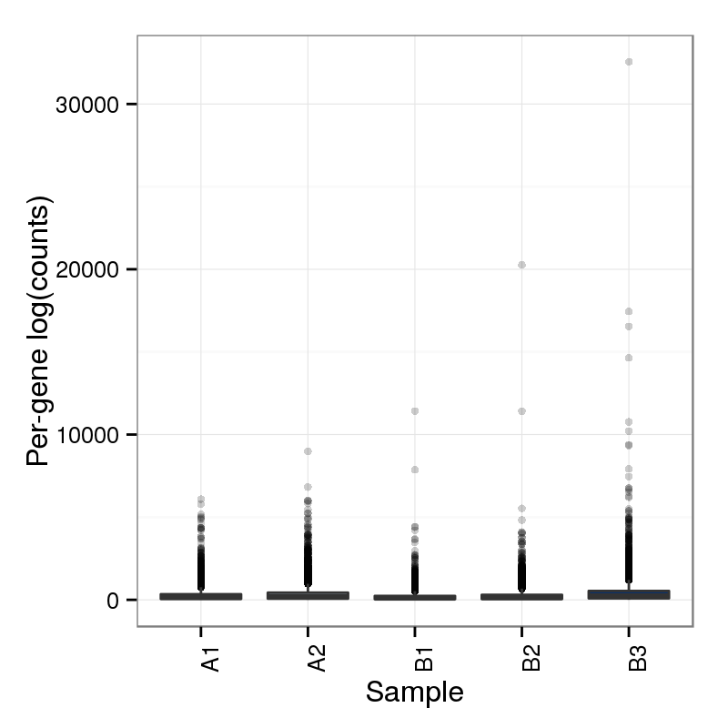

```r
print(fun_boxplot)
```

```r
log_boxplot = my_boxplot(df=fun, scale="log")
```

```r
## Using id as id variables
```

```r
print(log_boxplot)
```

[figure not shown]

```r
## Warning: Removed 267 rows containing non-finite values (stat_boxplot).
```

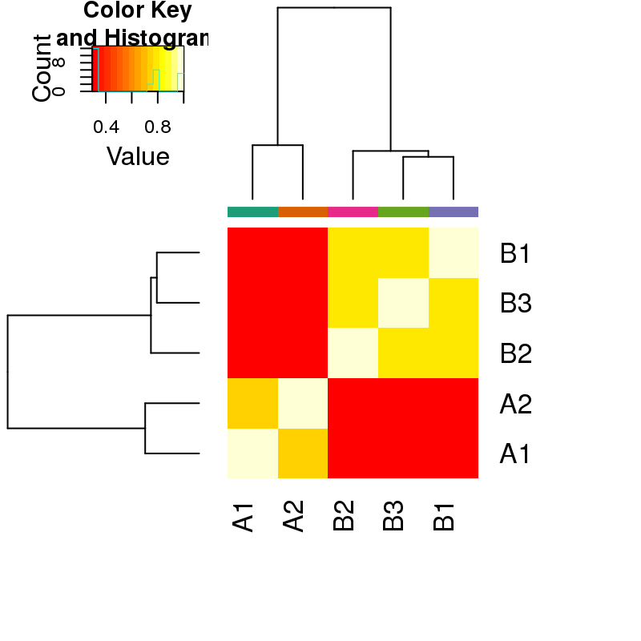

```r
## Something is weird in my R session, I changed these functions to not require
## the colors= argument but the R session does not seem to be seeing my change
## despite me running devtools::load_all("~/myr")  oh well
my_corheat(df=fun, colors=my_colors)
```

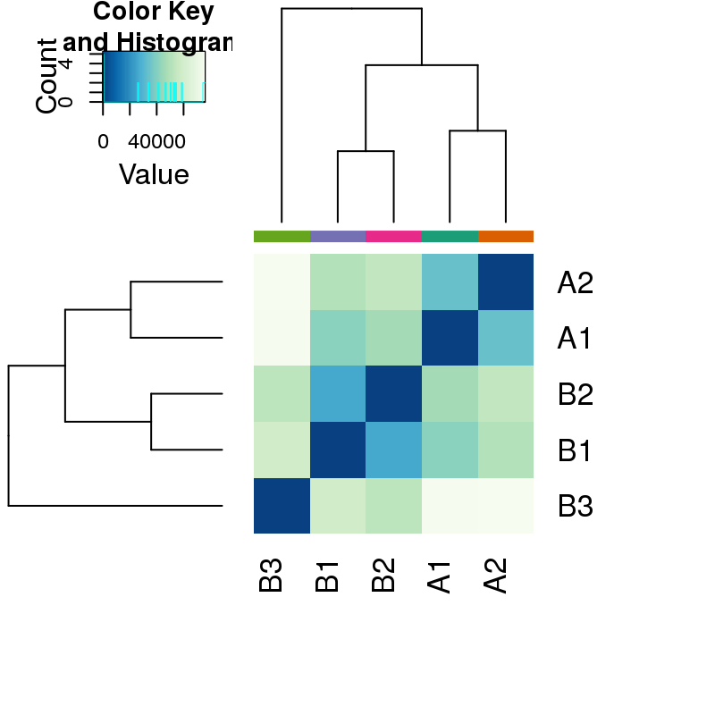

```r
my_disheat(df=fun, colors=my_colors)
```

```r
my_smc(df=fun, colors=my_colors)
```

[figure not shown]

```r
my_libsize(df=fun)
```

```r
## [1] "Adding log10"
```

[figure not shown]

```r
my_qq_all(df=fun)
```

```r
## Warning in KernSmooth::bkde2D(x, bandwidth = bandwidth, gridsize = nbin, :
## Binning grid too coarse for current (small) bandwidth: consider increasing
## 'gridsize'
```

```r
## Warning in KernSmooth::bkde2D(x, bandwidth = bandwidth, gridsize = nbin, :
## Binning grid too coarse for current (small) bandwidth: consider increasing
## 'gridsize'
```

```r
## Warning in KernSmooth::bkde2D(x, bandwidth = bandwidth, gridsize = nbin, :
## Binning grid too coarse for current (small) bandwidth: consider increasing
## 'gridsize'
```

[figure not shown]

[figure not shown]

```r
## $logs
##
## $ratios
##
## $medians
## $medians[[1]]
## [1] -0.2624
##
## $medians[[2]]
## [1] 0.02623
##
## $medians[[3]]
## [1] -0.5953
##
## $medians[[4]]
## [1] -0.37
##
## $medians[[5]]
## [1] 0.2198
```

```r
## There are other graphs which require a design or an expt class.
## my_pca, sample_heatmap, my_smd, graph_nonzero
```

### Normalizing data

RNAseq data must be normalized. Here is one easy method:

```r
## normalize_expt will do this on the expt class, replace the expressionset therein, and
## make a backup of the data inside the expt class.
ql2cpm = my_norm(df=fun)  ## defaults to log2(CPM(quantile(data)))
head(ql2cpm)
```

```r
## An object of class "DGEList"
## $counts
##            A1  A2  B1  B2   B3
## gene_1_F   50 341 159 151  301
## gene_2_T  115  96 273 198 1073
## gene_3_F   49  28  27  44   30
## gene_4_F   39  92  16  31   20
## gene_5_F   68  82 100 125  196
## gene_6_F 1629 708 637 747 1098
##
## $samples
##    group lib.size norm.factors
## A1     1  2702976            1
## A2     1  3492339            1
## B1     1  1901003            1
## B2     1  2435775            1
## B3     1  4378926            1
```

```r
## size factor, tmm, rle, upperQuartile all require a design matrix.
```

### Voom/limma etc

The following are examples of some fun analyses. They generally want a full expressionset and so I won't tell R to evaluate the following block.

```r
## expt_subset() will pull pieces out of an expt class for simple comparisons
epi_subset = expt_subset(all_qcpml2, "condition=='clbr_epi'|condition=='cl14_epi'")
## graph the metrics of a subset of the data
epi_graphs = graph_metrics(expt=epi_subset)
epi_graphs$norm_pcaplot
epi_graphs$norm_disheat
epi_graphs$norm_corheat
## Simple comparison will take the first condition as control and the second
## as experimental
epi_comparison = simple_comparison(epi_subset)
epi_table = epi_comparison$table
epi_comparison$pvalue_histogram
epi_comparison$volcano_plot
epi_comparison$ma_plot
epi_comparison$coefficient_scatter
```

### A cell-means model using all conditions and batches

```r
## acb stands for "kept_conditions_batches"  which takes too long to
## type when setting up the contrasts.
acb = paste0(kept_qcpml2$conditions, kept_qcpml2$batches)
kept_data = exprs(kept_qcpml2$expressionset)
table(acb)
## The invocation of table() keptows me to count up the contribution of
## each condition/batch combination to the whole data set.

## Doing this (as I understand it) means I do nothave to worry about
## balanced samples so much, but must be more careful to understand
## the relative contribution of each sample type to the entire data
## set.

complete_model = model.matrix(~0 + acb)
complete_fit = lmFit(kept_data, complete_model)
complete_voom = my_voom(kept_data, complete_model)
complete_voom$plot
complete_model
## This is an example of what happens when I have heterogenous numbers of samples
## on each side of a contrast, so that a normal design matrix of conditions + batches
## would not work, so instead I add up the contributions of each batch (capital letters)
## and average them out, then use the resulting terms in the various contrasts below.
epi_cl14 = "acbcl14_epiF"
epi_clbr = "acbclbr_epiE"
tryp_cl14 = "(acbcl14_trypB + acbcl14_trypD + acbcl14_trypG) / 3"
tryp_clbr = "acbclbr_trypG"
a60_cl14 =  "(acbcl14_a60A * 2/3) + (acbcl14_a60B * 1/3)"
a60_clbr = "acbclbr_a60A"
a96_cl14 = "acbcl14_a96C"
a96_clbr = "acbclbr_a96C"
epi_cl14clbr = paste0("(",epi_cl14,")", "  -  ", "(",epi_clbr,")")
tryp_cl14clbr = paste0("(",tryp_cl14,")", "  -  ", "(",tryp_clbr,")")
a60_cl14clbr = paste0("(",a60_cl14,")", "  -  ", "(",a60_clbr,")")
a96_cl14clbr = paste0("(",a96_cl14,")", "  -  ", "(",a96_clbr,")")
epitryp_cl14 = paste0("(",tryp_cl14,")", "  -  ", "(",epi_cl14,")")
epitryp_clbr = paste0("(",tryp_clbr,")", "  -  ", "(",epi_clbr,")")
epia60_cl14 = paste0("(",a60_cl14,")", "  -  ", "(",epi_cl14,")")
epia60_clbr = paste0("(",a60_clbr,")", "  -  ", "(",epi_clbr,")")
a60a96_cl14 = paste0("(",a96_cl14,")", "  -  ", "(",a60_cl14,")")
a60a96_clbr = paste0("(",a96_clbr,")", "  -  ", "(",a60_clbr,")")
a60tryp_cl14 = paste0("(",tryp_cl14,")", "  -  ", "(",a60_cl14,")")
a60tryp_clbr = paste0("(",tryp_clbr,")", "  -  ", "(",a60_clbr,")")
## The following contrast is messed up in some as of yet unknown way.
epitryp_cl14clbr = paste0("(",epitryp_cl14,")", "  -  ", "(",epitryp_clbr,")")
## So I will add some more contrasts using data which doesn't get screwed up
epia60_cl14clbr = paste0("(",epia60_cl14,")", "  -  ", "(",epia60_clbr,")")
a60tryp_cl14clbr = paste0("(",a60tryp_cl14,")", "  -  ", "(",a60tryp_clbr,")")
a60a96_cl14clbr = paste0("(",a60a96_cl14,")", "  -  ", "(",a60a96_clbr,")")

complete_contrasts_v2 = makeContrasts(
    epi_cl14=epi_cl14,
    epi_clbr=epi_clbr,
    tryp_cl14=tryp_cl14,
    tryp_clbr=tryp_clbr,
    a60_cl14=a60_cl14,
    a60_clbr=a60_clbr,
    a96_cl14=a96_cl14,
    a96_clbr=a96_clbr,
    epi_cl14clbr=epi_cl14clbr,
    tryp_cl14clbr=tryp_cl14clbr,
    a60_cl14clbr=a60_cl14clbr,
    a96_cl14clbr=a96_cl14clbr,
    epitryp_cl14=epitryp_cl14,
    epitryp_clbr=epitryp_clbr,
    epia60_cl14=epia60_cl14,
    epia60_clbr=epia60_clbr,
    a60a96_cl14=a60a96_cl14,
    a60a96_clbr=a60a96_clbr,
    a60tryp_cl14=a60tryp_cl14,
    a60tryp_clbr=a60tryp_clbr,
    epitryp_cl14clbr=epitryp_cl14clbr,
    epia60_cl14clbr=epia60_cl14clbr,
    a60tryp_cl14clbr=a60tryp_cl14clbr,
    a60a96_cl14clbr=a60a96_cl14clbr,
    levels=complete_voom$design)
## This colnames() is annoyingly necessary to avoid really obnoxious contrast names.
colnames(complete_contrasts_v2) = c("epi_cl14","epi_clbr","tryp_cl14","tryp_clbr","a60_cl14","a60_clbr","a96_cl14","a96_clbr","epi_cl14clbr","tryp_cl14clbr","a60_cl14clbr","a96_cl14clbr","epitryp_cl14","epitryp_clbr","epia60_cl14","epia60_clbr","a60tryp_cl14","a60tryp_clbr","a60a96_cl14","a60a96_clbr","epitryp_cl14clbr","epia60_cl14clbr","a60tryp_cl14clbr","a60a96_cl14clbr")
kept_fits = contrasts.fit(complete_fit, complete_contrasts_v2)
kept_comparisons = eBayes(kept_fits)
```

### Clean conditions, batches

On the other hand, I would like to perform arbitrary comparisons among my data even when the batches and conditions look good, so I set up my model/contrast matrices a little strangely even then:

```r
all_data = exprs(norm_expt$expressionset)
complete_model = model.matrix(~0 + all_human_expt$conditions + all_human_expt$batches)
## Shorten the column names of the model so I don't have to type so much later...
tmpnames = colnames(complete_model)
tmpnames = gsub("all_human_expt[[:punct:]]","", tmpnames)
tmpnames = gsub("conditions","", tmpnames)
colnames(complete_model) = tmpnames
rm(tmpnames)

complete_voom = my_voom(all_data, complete_model)
complete_voom$plot
complete_fit = lmFit(complete_voom, complete_model)

all_contrasts = makeContrasts(
    ## Start with the simple coefficient groupings for each condition
    none4=none4,
    none24=none24,
    none48=none48,
    none72=none72,
    bead4=bead4,
    bead24=bead24,
    bead48=bead48,
    bead72=bead72,
    maj4=maj4,
    maj24=maj24,
    maj48=maj48,
    maj72=maj72,
    ama4=ama4,
    ama24=ama24,
    ama48=ama48,
    ama72=ama72,
    ## Now do a few simple comparisons
    ## compare beads to uninfected
    beadnone_4=bead4-none4,
    beadnone_24=bead24-none24,
    beadnone_48=bead48-none48,
    beadnone_72=bead72-none72,
    majnone_4=maj4-none4,
    majnone_24=maj24-none24,
    majnone_48=maj48-none48,
    majnone_72=maj72-none72,
    amanone_4=ama4-none4,
    amanone_24=ama24-none24,
    amanone_48=ama48-none48,
    amanone_72=ama72-none72,
    ## compare samples to beads
    majbead_4=maj4-bead4,
    majbead_24=maj24-bead24,
    majbead_48=maj48-bead48,
    majbead_72=maj72-bead72,
    amabead_4=ama4-bead4,
    amabead_24=ama24-bead24,
    amabead_48=ama48-bead48,
    amabead_72=ama72-bead72,
    ## (x-z)-(a-b)
    ## Use this to compare major and amazonensis
    amamaj_bead_4=(ama4-bead4)-(maj4-bead4),
    amamaj_bead_24=(ama24-bead24)-(maj24-bead24),
    amamaj_bead_48=(ama48-bead48)-(maj48-bead48),
    amamaj_bead_72=(ama72-bead72)-(maj72-bead72),
    ## (c-d)-(e-f) where c/d are: (amazon|major/none)/(beads/none)
    majbead_none_4=(maj4-none4)-(bead4-none4),
    majbead_none_24=(maj24-none24)-(bead24-none24),
    majbead_none_48=(maj48-none48)-(bead48-none48),
    majbead_none_72=(maj72-none72)-(bead72-none72),
    amabead_none_4=(ama4-none4)-(bead4-none4),
    amabead_none_24=(ama24-none24)-(bead24-none24),
    amabead_none_48=(ama48-none48)-(bead48-none48),
    amabead_none_72=(ama72-none72)-(bead72-none72),
    levels=complete_voom$design)
all_fits = contrasts.fit(complete_fit, all_contrasts)
all_comparisons = eBayes(all_fits)
all_table = topTable(all_comparisons, adjust="fdr", n=nrow(all_data))
write.csv(all_comparisons, file="excel/all_tables.csv")
## write_limma() is a shortcut for writing out all the data structures
all_comparison_tables = write_limma(all_comparisons, excel=FALSE)
```

### Ontology searches

The following is an example of a simplified GO search given 20 groups of genes which are from an unannotated organism, but for which blast2GO was performed.

```r
for (iter in 1:20) {
    ## Pull the nth group
    subgroup = subset(ontology_info, group == iter)
    subgroup = subgroup[,c("transcript_id","start","end")]
    colnames(subgroup) = c("ID","start","end")
    subgroup_go = simple_goseq(subgroup, lengths=gene_lengths, goids=go_ids)
    ## Save my pictures as images/go_plots-groupN.pdf
    plot_filename = paste("images/go_plots-group", iter, ".pdf", sep="")
    ## I put a block inside the pdf() call just so I can
    ## have indentation to see the set of things being
    ## printed to the pdf file.
    group_trees = goseq_trees(subgroup, subgroup_go)
    pdf(file=plot_filename)
    ## Print the p-value histogram describing how >99% of the go
    ## categories are not in fact significant.
    print(subgroup_go$pvalue_histogram)
    ## mfp_plot/bpp_plot/ccp_plot are bar graphs showing the
    ## 'score' (ratio of genes with in the ontology / all genes) as a bar
    ## and ontology p-value as color.  Thus bigger bars with brighter colors
    ## are considered cooler in the context of the ontology.
    ## Please note that these are explicitly limited to the top ~12 categories
    ## in order to make sure they are readable.
    print(subgroup_go$mfp_plot)
    print(subgroup_go$bpp_plot)
    print(subgroup_go$ccp_plot)
    print(group_trees$MF)
    print(group_trees$BP)
    print(group_trees$CC)
    ## The file/sink operations tell goseq_trees to shut up.  It is a very
    ## chatty tool.  goseq_trees feeds the topGO tool the goseq data and
    ## tells it to plot its ontology trees images which describe the
    ## chosen ontology (molecular function/biological process/cell component)
    ## and the 'interesting' genes therein as boxes and colors.
    ##f = file()
    ##sink(file=f)
    ##close(f)
    dev.off()

    ## Write out the data tables in excel files: excel/group_tables-groupN.xls
    xls_filename = paste("excel/go_tables-group", iter, ".xls", sep="")
    sheetname = paste("mf_interesting-group", iter, sep="")
    write_xls(data=subgroup_go$mf_interesting, sheet=sheetname, file=xls_filename)
    sheetname = paste("mf_subset-group", iter, sep="")
    write_xls(data=subgroup_go$mf_subset, sheet=sheetname, file=xls_filename)
    sheetname = paste("bp_interesting-group", iter, sep="")
    write_xls(data=subgroup_go$bp_interesting , sheet=sheetname, file=xls_filename)
    sheetname = paste("bp_subset-group", iter, sep="")
    write_xls(data=subgroup_go$bp_subset, sheet=sheetname, file=xls_filename)
    sheetname = paste("cc_interesting-group", iter, sep="")
    write_xls(data=subgroup_go$cc_interesting , sheet=sheetname, file=xls_filename)
    sheetname = paste("cc_subset-group", iter, sep="")
    write_xls(data=subgroup_go$cc_subset, sheet=sheetname, file=xls_filename)
}
```

## Styles

```
output:
  rmarkdown::html_vignette:
    css: mystyles.css
```

## Figures

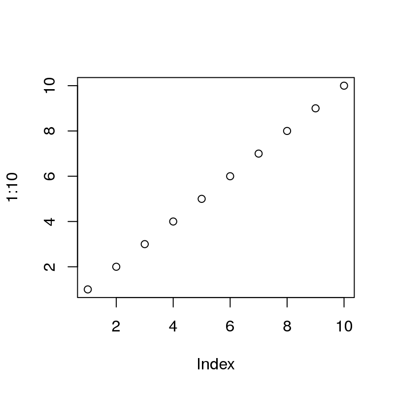

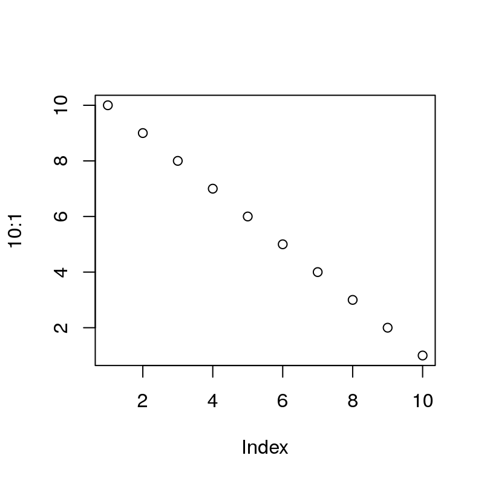

```r
plot(1:10)
plot(10:1)
```

You can enable figure captions by `fig_caption: yes` in YAML:

```
output:
  rmarkdown::html_vignette:
    fig_caption: yes
```

Then you can use the chunk option `fig.cap = "Your figure caption."` in **knitr**.

## More Examples

You can write math expressions, e.g. *Y* = *X**β* + *ε*, footnotes[^1], and tables, e.g. using `knitr::kable()`.

|  | mpg | cyl | disp | hp | drat | wt | qsec | vs | am | gear | carb |
| --- | --- | --- | --- | --- | --- | --- | --- | --- | --- | --- | --- |
| Mazda RX4 | 21.0 | 6 | 160.0 | 110 | 3.90 | 2.620 | 16.46 | 0 | 1 | 4 | 4 |
| Mazda RX4 Wag | 21.0 | 6 | 160.0 | 110 | 3.90 | 2.875 | 17.02 | 0 | 1 | 4 | 4 |
| Datsun 710 | 22.8 | 4 | 108.0 | 93 | 3.85 | 2.320 | 18.61 | 1 | 1 | 4 | 1 |
| Hornet 4 Drive | 21.4 | 6 | 258.0 | 110 | 3.08 | 3.215 | 19.44 | 1 | 0 | 3 | 1 |
| Hornet Sportabout | 18.7 | 8 | 360.0 | 175 | 3.15 | 3.440 | 17.02 | 0 | 0 | 3 | 2 |
| Valiant | 18.1 | 6 | 225.0 | 105 | 2.76 | 3.460 | 20.22 | 1 | 0 | 3 | 1 |
| Duster 360 | 14.3 | 8 | 360.0 | 245 | 3.21 | 3.570 | 15.84 | 0 | 0 | 3 | 4 |
| Merc 240D | 24.4 | 4 | 146.7 | 62 | 3.69 | 3.190 | 20.00 | 1 | 0 | 4 | 2 |
| Merc 230 | 22.8 | 4 | 140.8 | 95 | 3.92 | 3.150 | 22.90 | 1 | 0 | 4 | 2 |
| Merc 280 | 19.2 | 6 | 167.6 | 123 | 3.92 | 3.440 | 18.30 | 1 | 0 | 4 | 4 |

Also a quote using `>`:

> "He who gives up [code] safety for [code] speed deserves neither." ([via](https://twitter.com/hadleywickham/status/504368538874703872))

Styled with knitrBootstrap

[^1]: A footnote here.